# R Notebook - Descibing Data II

# Two Quantitative Variables

## Scatter plots

- A graph used to display data concerning 2 quantitative variables
- Can be used to explain the association between two vars, even in cases where there is not a clear relationship between variables.
- Correlation is a measure of the direction and strength of the relationship between 2 quantitative vars.
- Simple linear regression uses a var to predict a second one.

#### Remarks

In some studies 1 variable is used to explain or predict a 2nd var:

- Explanatory Variable or independent variable is used to explain variability in the 2nd var, aka response variable (x-axis)
- Response variable is the dependent variable (y-axis)

#### Examining Scatter Plots

1. Direction: Positive or negative
2. Form: linear or non-linear
3. Strength: weak, moderate , strong
4. Bivariate outliers

##### Linear Relationships

Occurs when the “line of best fit” describing the relationship between variables is a straight line:

- Can be positive - both variables increase together -> direct relationship
- Negative - 1 variable increases as another decreases -> indirect relationship

##### Bivariate Outlier

Observations that do not fit with the general pattern of the observations

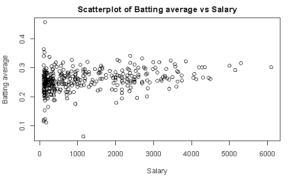

```r
# Data concerning baseball statistics and salaries from the 1991 and 1992 seasons is available at: http://www.amstat.org/publications/jse/datasets/baseball.dat.txt
# The scatterplot below shows the relationship between salary and batting average for the 337 baseball players in this sample.

baseball=read.table("../datasets/baseball.dat.txt")
plot(baseball[,c(1,2)], xlab="Salary", ylab="Batting average", main="Scatterplot of Batting average vs Salary")
```

```r
NA
NA
```

From the example above:

- No clear meaningful relationship between salary and batting average
- More salaries at the low end than at the top end, without affecting the batting average

```r
# Data concerning the heights and shoe sizes of 408 students were retrieved from: http://www.amstat.org/publications/jse/v20n3/mclaren/shoesize.xls
# The scatterplot below was constructed to show the relationship between height and shoe size.
shoesize=readxl::read_xls("../datasets/shoesize.xls",sheet = 1)
# showing the contents of the shoesize dataset
str(shoesize)
```

```
tibble [408 × 4] (S3: tbl_df/tbl/data.frame)
 $ Index : num [1:408] 1 2 3 4 5 6 7 8 9 10 ...
 $ Gender: chr [1:408] "F" "F" "F" "F" ...
 $ Size  : num [1:408] 5.5 6 7 8 8 9 7.5 6.5 5 6 ...
 $ Height: num [1:408] 60 60 60 60 60 60 60 60 60 61 ...
```

```r
#
shoesize=shoesize[,c(1,2,3,4)]
#transforming into a table
shoesize
```

| Index | Gender | Size | Height |
| --- | --- | --- | --- |
| 1 | F | 5.5 | 60.00 |
| 2 | F | 6.0 | 60.00 |
| 3 | F | 7.0 | 60.00 |
| 4 | F | 8.0 | 60.00 |
| 5 | F | 8.0 | 60.00 |
| 6 | F | 9.0 | 60.00 |
| 7 | F | 7.5 | 60.00 |
| 8 | F | 6.5 | 60.00 |
| 9 | F | 5.0 | 60.00 |
| 10 | F | 6.0 | 61.00 |

[output cut: 398 more lines]

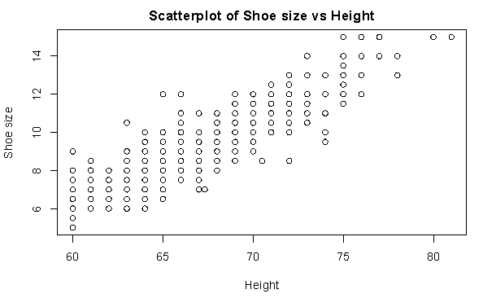

```r
# creting the scatter plot between height and Size
plot(shoesize$Height,shoesize$Size, xlab="Height", ylab="Shoe size",main="Scatterplot of Shoe size vs Height")
```

```r
NA
NA
NA
```

In this case, we can assume:

- Linear Positive relationship between variables
- Magnitude of relationship is strong (subjective analysis)
- No outliers (subjective analysis)

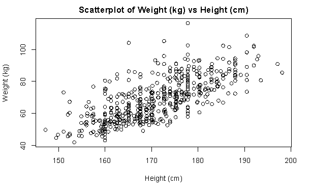

```r
# Data concerning body measurements from 507 individuals retrieved from:
# https://ww2.amstat.org/publications/jse/datasets/body.dat.txt
# https://ww2.amstat.org/publications/jse/datasets/body.txt

body=read.table("../datasets/body.dat.txt",header=FALSE)
names(body)[c(23,24)]=c("Weight","Height")
plot(body$Height,
     body$Weight,
     xlab="Height (cm)",
     ylab="Weight (kg)",
     main="Scatterplot of Weight (kg) vs Height (cm)")
```

In the example above:

- Linear positive relationship
- Moderately strong relationship
- Some bivariate outliers

```r
# Data concerning sales at student-run coffee shop were retrieved from:
# http://www.amstat.org/publications/jse/v19n1/cafedata.xls
# http://www.amstat.org/publications/jse/v19n1/cafedata documentation.

cafe = read_xls("../datasets/cafedata.xls")
# describing the data set
str(cafe)
```

```
tibble [48 × 22] (S3: tbl_df/tbl/data.frame)
 $ t                        : num [1:48] 1 2 3 4 5 6 7 8 9 10 ...
 $ Date                     : POSIXct[1:48], format: "2010-01-19" "2010-01-20" "2010-01-21" "2010-01-22" ...
 $ Day Code                 : num [1:48] 2 3 4 5 1 2 3 4 5 1 ...
 $ Day of Week              : chr [1:48] "Tue" "Wed" "Thu" "Fri" ...
 $ Bread Sand Sold          : chr [1:48] "5" "6" "8" "4" ...
 $ Bread Sand Waste         : chr [1:48] "3" "8" "2" "2" ...
 $ Wraps Sold               : chr [1:48] "25" "7" "14" "5" ...
 $ Wraps Waste              : chr [1:48] "5" "17" "0" "7" ...
 $ Muffins Sold             : chr [1:48] "5" "3" "4" "5" ...
 $ Muffins Waste            : chr [1:48] "1" "5" "0" "0" ...
 $ Cookies Sold             : chr [1:48] "5" "1" "1" "3" ...
 $ Cookies Waste            : chr [1:48] "3" "6" "0" "1" ...
 $ Fruit Cup Sold           : chr [1:48] "1" "0" "0" "3" ...
 $ Fruit Cup Waste          : chr [1:48] "4" "3" "3" "0" ...
 $ Chips                    : chr [1:48] "12" "0" "0" "20" ...
 $ Juices                   : chr [1:48] "8" "0" "13" "0" ...
 $ Sodas                    : chr [1:48] "20" "13" "23" "13" ...
 $ Coffees                  : chr [1:48] "41" "33" "34" "27" ...
 $ Total Soda and Coffee    : chr [1:48] "61" "46" "57" "40" ...
 $ Sales                    : num [1:48] 200 196 103 163 102 ...
 $ Max Daily Temperature (F): num [1:48] 36 34 39 40 36 26 34 33 20 37 ...
 $ Total Items Wasted       : chr [1:48] "16" "39" "5" "10" ...
```

```
NAs introduced by coercion
```

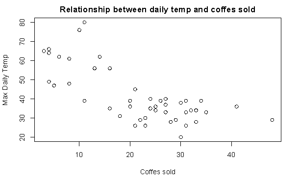

```r
# plotting the scatter plot
plot(cafe$Coffees,
     cafe$`Max Daily Temperature (F)`,
     xlab = "Coffes sold",
     ylab = "Max Daily Temp",
     main = "Relationship between daily temp and coffes sold")
```

From the example above we can tell:

- Linear negative relationship
- Moderately strong relation magnitude
- Appear to have no outliers

## Correlations

### Covariance

linear relationship between a pair of quantitative measures x1, x,…, xn and y1, y2, …, yn on the same sample of n individuals.

cov(x,y) = s^2(x,y) = 1/(n-1) Sum [variance(xi-mean(x))*(yi-mean(y))]

- Positive covariance: x, y variables are more often obove or below the mean in tandem (the terms (xi-mean(x)) and (yi-mean(y)) are more likely to be positive)

#### Remark

covariance as a measure of association has the drawback that its value depends on the units of measurement. This shortcoming is remedied by using the correlation.

### Correlation

A measure of the direction and strength of the relationship between two variables.

We will be using the Pearson’s correlation coefficient (“ρ”) to measure the relationship between 2 vars.

Properties of Person’s ρ:

1. 1 ≤ ρ ≤ +1.
2. For a positive association, ρ > 0, for a negative association ρ < 0, if there is no relationship ρ = 0.
3. The closer ρ is to 0 the weaker the relationship and the closer to +1 or -1 the stronger the relationship (e.g., ρ = 0.88 is a stronger relationship than ρ = +0.60).
4. The sign of the correlation provides direction only.
5. Correlation is unit free; the x and y variables do NOT need to be on the same scale (e.g., it is possible to compute the correlation between height in centimeters and weight in pounds)
6. It does not matter which variable you label as x and which you label as y. The correlation between x and y is equal to the correlation between y and x.

The following table may serve as a guideline when evaluating correlation coefficients:

| Absolute Value of ρ | Strength of the Relationship |
| --- | --- |
| 0-0.2 | Very weak |
| 0.2-0.4 | Weak |
| 0.4-0.6 | Moderate |
| 0.6-0.8 | Strong |
| 0.8-1.0 | Very strong |

**NOTE:** This is just a guide. The analysis should take into account the data context, e.g. in social sciences studies we often get weaker correlation values.

#### Remarks

- **IMPORTANT**: **Correlation does not mean Causation** -> a strong relationship between x and y does not mean the x causes y. It is possible that y causes x , or that a confounding variable causes both x and y .
- Pearson’s ρ should only be used when there is a linear relationship between x and y . A scatterplot should be constructed before computing Pearson’s ρ to confirm that the relationship is not non-linear.
- **IMPORTANT:** Pearson’s ρ is not resistant to outliers. Influential outliers are points in a data set that increase or decrease the correlation coefficient.

Correlation in R:

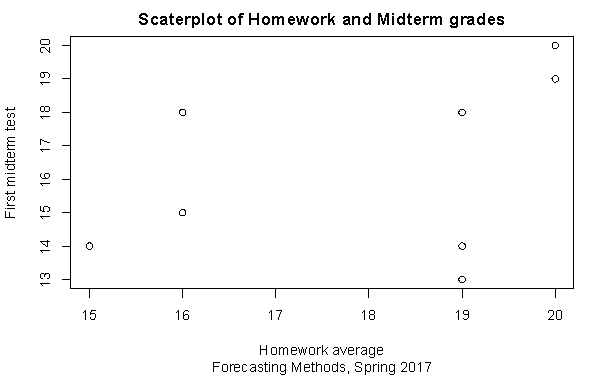

```r
 # Loading the data
HW=c(16,20,19,19,16,15,20,20,19)
MT=c(15,19,13,14,18,14,20,20,18)
# Plotting
plot(HW, MT,
     xlab="Homework average",
     ylab="First midterm test",
     main="Scaterplot of Homework and Midterm grades",
     sub="Forecasting Methods, Spring 2017")
```

We can observe:

- There’s a linear positve relationship
- Moderate magnitude
- Outliers exist

Let’s draw a line of best fit

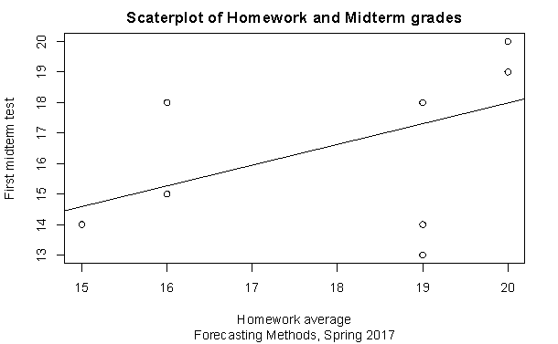

```r
 # Loading the data
HW=c(16,20,19,19,16,15,20,20,19)
MT=c(15,19,13,14,18,14,20,20,18)
# Plotting
plot(HW, MT,
     xlab="Homework average",
     ylab="First midterm test",
     main="Scaterplot of Homework and Midterm grades",
     sub="Forecasting Methods, Spring 2017")
abline(lm(MT~HW))
```

Now we calculate perason’s ρ

```r
HW=c(16,20,19,19,16,15,20,20,19)
MT=c(15,19,13,14,18,14,20,20,18)
cor(MT, HW)
```

```
[1] 0.4865677
```

It’s a moderate relationship in terms of magnitude

## Simple Linear Regression

Use of one or more explanatory variables to predict a response variable

By **LINEAR** we can assume:

- Uses a straight line to predict the response variable based on the explanatory var.

By **SIMPLE** we can assume:

- Only one exploratory variable (If there are two or more explanatory variables, then multiple linear regression is necessary.)

Additional remarks:

- In regression it **DOES MATTER** which variable is in the x-axis or y-axis:
  - X - Explanatory Variable
  - Y - Response Variable
- Both X and Y must be quantitative variables (recall y=b+mx, where m is the slope and b the interception point in the y-axis) -> if x=0 then y=b.

#### Remark

- Simple Linear Regression Line: Sample -> y = a + bx
- Simple Linear Regression Line: Population -> y = α + βx

Additionally

- Simple linear regression uses data from a sample to construct the line of best fit.
- But what makes a line “best fit”?
  - The most common method of constructing a simple linear regression line, and the only method that we will be using in this course, is the least squares method.

## Relations between multiple variables

We can use Scatter plots to examine the relationship between 2 vars and 2 groups

```r
# getting the dataset
body=read.table("../datasets/body.dat.txt",header=FALSE)
str(body)
```

```
'data.frame':   507 obs. of  25 variables:
 $ V1 : num  42.9 43.7 40.1 44.3 42.5 43.3 43.5 44.4 43.5 42 ...
 $ V2 : num  26 28.5 28.2 29.9 29.9 27 30 29.8 26.5 28 ...
 $ V3 : num  31.5 33.5 33.3 34 34 31.5 34 33.2 32.1 34 ...
 $ V4 : num  17.7 16.9 20.9 18.4 21.5 19.6 21.9 21.8 15.5 22.5 ...
 $ V5 : num  28 30.8 31.7 28.2 29.4 31.3 31.7 28.8 27.5 28 ...
 $ V6 : num  13.1 14 13.9 13.9 15.2 14 16.1 15.1 14.1 15.6 ...
 $ V7 : num  10.4 11.8 10.9 11.2 11.6 11.5 12.5 11.9 11.2 12 ...
 $ V8 : num  18.8 20.6 19.7 20.9 20.7 18.8 20.8 21 18.9 21.1 ...
 $ V9 : num  14.1 15.1 14.1 15 14.9 13.9 15.6 14.6 13.2 15 ...
 $ V10: num  106 110 115 104 108 ...
 $ V11: num  89.5 97 97.5 97 97.5 ...
 $ V12: num  71.5 79 83.2 77.8 80 82.5 82 76.8 68.5 77.5 ...
 $ V13: num  74.5 86.5 82.9 78.8 82.5 80.1 84 80.5 69 81.5 ...
 $ V14: num  93.5 94.8 95 94 98.5 95.3 101 98 89.5 99.8 ...
 $ V15: num  51.5 51.5 57.3 53 55.4 57.5 60.9 56 50 59.8 ...
 $ V16: num  32.5 34.4 33.4 31 32 33 42.4 34.1 33 36.5 ...
 $ V17: num  26 28 28.8 26.2 28.4 28 32.3 28 26 29.2 ...
 $ V18: num  34.5 36.5 37 37 37.7 36.6 40.1 39.2 35.5 38.3 ...
 $ V19: num  36.5 37.5 37.3 34.8 38.6 36.1 40.3 36.7 35 38.6 ...
 $ V20: num  23.5 24.5 21.9 23 24.4 23.5 23.6 22.5 22 22.2 ...
 $ V21: num  16.5 17 16.9 16.6 18 16.9 18.8 18 16.5 16.9 ...
 $ V22: num  21 23 28 23 22 21 26 27 23 21 ...
 $ V23: num  65.6 71.8 80.7 72.6 78.8 74.8 86.4 78.4 62 81.6 ...
 $ V24: num  174 175 194 186 187 ...
 $ V25: int  1 1 1 1 1 1 1 1 1 1 ...
```

```r
# Setting the column names
names(body)[c(23,24,25)]=c("Weight","Height","Gender")
# Converting the discrete values to Female, Male labels
body$Gender<-factor(body$Gender, levels=c(0,1), labels=c("Female","Male"))
body$Gender
```

```
  [1] Male   Male   Male   Male   Male   Male   Male   Male   Male   Male   Male   Male   Male   Male   Male   Male
 [17] Male   Male   Male   Male   Male   Male   Male   Male   Male   Male   Male   Male   Male   Male   Male   Male
 [33] Male   Male   Male   Male   Male   Male   Male   Male   Male   Male   Male   Male   Male   Male   Male   Male
 [49] Male   Male   Male   Male   Male   Male   Male   Male   Male   Male   Male   Male   Male   Male   Male   Male
 [65] Male   Male   Male   Male   Male   Male   Male   Male   Male   Male   Male   Male   Male   Male   Male   Male
 [81] Male   Male   Male   Male   Male   Male   Male   Male   Male   Male   Male   Male   Male   Male   Male   Male
 [97] Male   Male   Male   Male   Male   Male   Male   Male   Male   Male   Male   Male   Male   Male   Male   Male
[113] Male   Male   Male   Male   Male   Male   Male   Male   Male   Male   Male   Male   Male   Male   Male   Male
[129] Male   Male   Male   Male   Male   Male   Male   Male   Male   Male   Male   Male   Male   Male   Male   Male
[145] Male   Male   Male   Male   Male   Male   Male   Male   Male   Male   Male   Male   Male   Male   Male   Male
[161] Male   Male   Male   Male   Male   Male   Male   Male   Male   Male   Male   Male   Male   Male   Male   Male
[177] Male   Male   Male   Male   Male   Male   Male   Male   Male   Male   Male   Male   Male   Male   Male   Male
[193] Male   Male   Male   Male   Male   Male   Male   Male   Male   Male   Male   Male   Male   Male   Male   Male
[209] Male   Male   Male   Male   Male   Male   Male   Male   Male   Male   Male   Male   Male   Male   Male   Male
[225] Male   Male   Male   Male   Male   Male   Male   Male   Male   Male   Male   Male   Male   Male   Male   Male
```

[output cut: 18 more lines]

```r
# creating the men and women groups
men=subset(body, levels(body$Gender)=="Female")
women=subset(body, levels(body$Gender)=="Male")
# plotting the scatter plot
plot(men$Height,men$Weight,
     xlab="Height (cm)",
     ylab="Weight (kg)",
     main="Scatterplot of Weight (kg) vs Height (cm)",
     col="red",
     pch=2)
# adding the woman points for height and weight
points(women$Height,women$Weight, col="blue", pch=3)
```

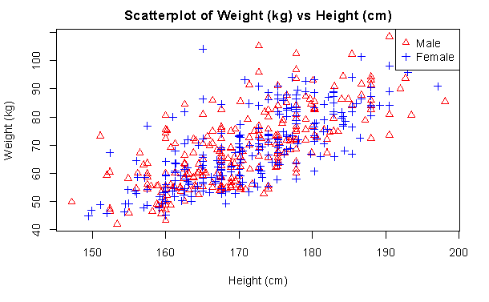

```r
legend("topright",
       c('Male', 'Female'),
       col=c("red","blue"),
       pch=c(2,3))
```

We can assume a linear positive and moderately strong relationship between weight and height.

#### Remark

There may exist confounding variables interfering with the results, and in this cases we may need to separate the variables in our analysis -> e.g. the **Simpson’s Paradox:**

- A trend exists in several different groups but disappears or reverses when these groups are combined:
  - Often occurs in medical or social science studies.
  - Can be resolved when casual relationships are addressed.

## Time Series Plots

A time series plot displays time on the x -axis and a quantitative response variable on the y -axis.

- In other words, one quantitative variable is examined over time.

Before plotting the data is necessary to create a time series object containing the necessary meta information.

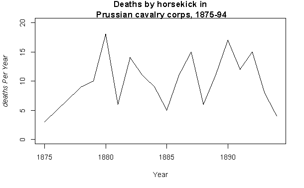

```r
# install.packages("pscl")
# library("pscl")
X <- tapply(prussian$y, prussian$year, sum)
names(X)=NULL
horse.deaths=ts(X, start=1875)
plot(horse.deaths, xlab="Year",
     ylab=expression(italic("deaths Per Year")),
     ylim=c(0,20),
     main="Deaths by horsekick in\n Prussian cavalry corps, 1875-94")
```

Example: Changes in Religious Affiliations

```r
Christian = c(66.31,63.97,61.08,61.11,61.57,63.68,60.22,60.92,59.42,57.8,56.05,52.8,52.05,50.54, 51.77,55.18,54.18,53.99,50.14,52.79,53.55,48.05)

Other = c(1.99,3.41,4.32,4.93,4.08,1.7,2.93,3.13,3.48,3.48, 3.39,3.79,4.39,2.98,3.23,4.66,4.00,4.17,5.99,3.33,6.19,5.60)

None = c(31.28,32.2,34.29,33.95,34.32,34.41,36.34,35.08, 36.68,38.49,40.38,42.66,43.02,45.06,43.75,39.5, 41.22,41.11,43.04,43.4,39.63,45.77)

Christian=ts(Christian, start=1983)
Other=ts(Other, start=1983)
None=ts(None, start=1983)

plot(Christian, ylab="%", ylim=c(0,70))
lines(Other, col=2)
```

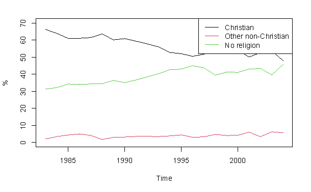

```r
lines(None, col=3)
legend("topright",
       c('Christian', 'Other non-Christian', 'No religion'),
       col=c(1,2,3),
       lty=1)
```

```r
NA
NA
```